# 2024 Regork Midterm Report - Vegetarian Expansion Analysis

Ryan Morris, Sam Pitstick, Rudra Agrawal

2024-10-11

## Midterm Report - Expansion of Vegetarian and Vegan options

### Introduction

#### Why Expand the Vegetarian/Vegan Categories

As we look ahead to the next year of business, a key focus for Regork is understanding emerging market trends and determining how best to capitalize on them. One trend that stands out is the increasing demand for plant-based foods that appeal to vegetarian and vegan consumers. According to data from the Plant Based Foods Association, sales of plant-based foods have grown by 8.1% across all categories, with the overall market exceeding $3.1 billion in sales.

In this report, we analyze our sales data to assess whether similar growth trends are occurring within Regork’s product categories. Using this data, we will identify which categories have the greatest potential for expansion and determine the key demographics we should target with marketing efforts. Our analysis will provide insights that will enable Regork to strategically expand its offerings in the vegetarian and vegan categories, helping to capture a greater share of this growing market.

### Packages/Libraries Required

#### The following packages and libraries were used:

- `complete journey` - Data package containing information on retail transactions from 2469 households during the 2016-2017 year.
- `tidyverse` - A collection of open- source packages that offer methods to import, tidy, manipulate, and visualize data.
- `knitr` - Offers methods to help generate reports within R markdown
- `ggplot2` - part of tidyverse, this package offers several methods to help display data in a variety of geoms

```r
#Load tidyverse, completejourney, plotly, shiny  packages
suppressMessages(library(tidyverse))
suppressMessages(library(completejourney))
```

### Data Aggregation and Tidying

```r
#Get Transaction Data
transactions <- get_transactions()

#Join Transactions and Products tables for later use
productTrans <- transactions %>%
  inner_join(products, by = "product_id")

#Create Transaction and Product join while filtering for:
#"FROZEN MEAT (VEGETARIAN)" "RICE BEVERAGE" "SOY BEVERAGE" "SOY/RICE MILK"
#"TOFU" "MEATLESS/VEGETARIAN" "NON-DAIRY CHEESE" "VEGETARIAN MEATS" "VEGETARIAN MISC"
VegeTransactions <- products %>%
  inner_join(transactions, by = "product_id") %>%
  filter(product_type %in% c("FROZEN MEAT (VEGETARIAN)", "RICE BEVERAGE", "SOY BEVERAGE", "SOY/RICE MILK", "TOFU", "MEATLESS/VEGETARIAN", "NON-DAIRY CHEESE", "VEGETARIAN MEATS", "VEGETARIAN MISC"))

#Create lists of product ids related to our products of interest:
VegeProducts <- VegeTransactions %>%
  filter(product_type %in% c("FROZEN MEAT (VEGETARIAN)", "RICE BEVERAGE", "SOY BEVERAGE", "SOY/RICE MILK", "TOFU", "MEATLESS/VEGETARIAN", "NON-DAIRY CHEESE", "VEGETARIAN MEATS", "VEGETARIAN MISC")) %>%
  group_by(product_type) %>%
  summarize(Unique_Product_Ids = list(unique(product_id)), .groups = 'drop')

#Find the Total Sales Value for products of interest
TotalVegeSales <- VegeTransactions %>%
  summarize(TotalSales = sum(sales_value))

#Find Total sales value for products of interest by store location
VegaStoreVolumes <- VegeTransactions %>%
  group_by(store_id) %>%
  summarize(TotalStoreSales = sum(sales_value)) %>%
  arrange(desc(TotalStoreSales))

# Color palette
my_colors <- c("#f5fd3c", "#14D90D", "#33FFBD", "#9e06a2",  "#d11fff", "#f526df",  "#FF33A6", "#3380FF",  "#34c9f5",  "#e2c505","#55ad01", "#000000")

#Join the demographics table with VegeTransactions
VegeDemoTransactions <- VegeTransactions %>%
  inner_join(demographics, by = "household_id")

#Group the total sales by income levels and age
VegeIncomeSales <- VegeDemoTransactions %>%
  group_by(income, age) %>%
  summarize(TotalIncomeSales = sum(sales_value), .groups = 'drop')

#Group the total sales by Household Compositions
VegeFamilyCompSales <- VegeDemoTransactions %>%
  group_by(household_comp) %>%
  summarize(TotalAgeSales = sum(sales_value))

#Create a summary of each product types total sales
VegeSalesByProduct <- VegeTransactions %>%
  group_by(product_type) %>%
  summarize(TotalSales = sum(sales_value)) %>%
  arrange(desc(TotalSales))

# Filter down table to relevant information for transactions, and then to top 5 performers in Vegetarian category.
#Group by product type and week for graphing
VegeProductWeeklySales <- VegeTransactions %>%
  select(c("product_type", "sales_value", "week", "transaction_timestamp")) %>%
  filter(product_type %in% c("SOY BEVERAGE", "SOY/RICE MILK","FROZEN MEAT (VEGETARIAN)", "VEGETARIAN MEATS", "TOFU")) %>%
  group_by(product_type, week)

#Calculate the Percentage Change in the Top 5 Categories
VegeProductWeeklySalesPerc <- VegeProductWeeklySales %>%
  arrange(product_type, week) %>%
  group_by(product_type) %>%
  mutate(PercentChange = ifelse(lag(sales_value) == 0, NA, (sales_value - lag(sales_value)) / lag(sales_value) * 100)) %>%
  summarize(averagePercChange = mean(PercentChange, na.rm = TRUE))

#Create Smooth graph tracking sales trends of top 5 performers
VegeWeeklySalesTrends <- VegeProductWeeklySales %>%
  ggplot(aes(x = week, y = sales_value, colour = product_type)) +
  geom_smooth(method = 'loess', formula = y ~ x) +
  labs(title = "Weekly Sales by Vegetarian/Vegan Item in 2017",
        subtitle = "Sales Trends of Top 5 Performers in the Category",
        x = "Week of 2017",
        y = "Total Sales($)",
        color = "Products",
        caption = "https://github.com/bradleyboehmke/completejourney")

#Create Pie Graph of Sales based on Income Levels
VegePieIncome <- VegeDemoTransactions %>%
  ggplot(aes(x = "", sales_value, fill = income)) +
  geom_bar(stat = 'identity', width = 1, show.legend = TRUE) +
  coord_polar("y", start = 0) +
  scale_fill_manual(values = my_colors) +
  theme_void() +
  labs(title = "Percentage of Customers by Income Range",
       caption = "https://github.com/bradleyboehmke/completejourney")


#Create Pie Graph of Sales based on Ages
VegePieAge <- VegeDemoTransactions %>%
  ggplot(aes(x = "", sales_value, fill = age)) +
  geom_bar(stat = 'identity', width = 1, show.legend = TRUE) +
  coord_polar("y", start = 0) +
  scale_fill_manual(values = my_colors) +
  theme_void() +
  labs(title = "Percentage of Customers by Age",
       caption = "https://github.com/bradleyboehmke/completejourney")


#Create Pie Graph of Sales based on Household comps - Changed
VegePieHouseComp <- VegeDemoTransactions %>%
  ggplot(aes(x = factor(1), sales_value, fill = household_comp)) +
  geom_bar(stat = 'identity', width = 1, show.legend = TRUE) +
  coord_polar("y", start = 0) +
  scale_fill_manual(values = my_colors) +
  theme_void() +
  labs(title = "Household Compositions that Purchase Vegetarian Items",
       caption = "https://github.com/bradleyboehmke/completejourney")


#Create graph for Number of transactions at store locations
VegeStoreGraph <- VegeTransactions %>%
  group_by(store_id) %>%
  summarise(TransactionCount = n()) %>%
  arrange(desc(TransactionCount)) %>%
  slice_head(n = 10) %>%
  ggplot(aes(x = as.factor(store_id), y = TransactionCount, fill = as.factor(store_id))) +
  geom_bar(stat = "identity", show.legend = FALSE) +
  scale_fill_manual(values = my_colors) +
  theme_minimal() +
  labs(title = "Vegetarian Related Transactions by Store Locations",
        subtitle = "About",
        x = "Store ID",
        y = "Number of Transactions",
        color = "Household size",
        caption = "https://github.com/bradleyboehmke/completejourney")

#Find the top ten products purchased with Vegetarian products

#Gather all the product id's of vegetarian items
VegeProducts <- VegeTransactions %>%
  filter(product_type %in% c("FROZEN MEAT (VEGETARIAN)", "RICE BEVERAGE", "SOY BEVERAGE", "SOY/RICE MILK", "TOFU", "MEATLESS/VEGETARIAN", "NON-DAIRY CHEESE", "VEGETARIAN MEATS", "VEGETARIAN MISC")) %>%
  group_by(product_type) %>%
  summarize(Unique_Product_Ids = list(unique(product_id)), .groups = 'drop')

#Store those ids as a single list
VegeUniqueIds <- VegeProducts %>% unlist(VegeProducts$Unique_Product_Ids)

#Use VegeUniqueIds to gather basket_id's including those products
VegeBaskets <- transactions %>%
  filter(product_id %in% VegeUniqueIds) %>%
  group_by(basket_id) %>%
  summarize(list(unique(basket_id)))

#store the basket ids as a single list
VegeUniqueBaskets <- unlist(VegeBaskets$`list(unique(basket_id))`)

#Use the VegeUniqueBaskets to filter relevant basket_ids and then gather all products
#in those baskets(minus vegetarian) and get a count of unique items
VegeAdjacentBaskets <- productTrans %>%
  filter(basket_id %in% VegeUniqueBaskets) %>%
  filter(!product_type %in%  c("FROZEN MEAT (VEGETARIAN)", "RICE BEVERAGE", "SOY BEVERAGE", "SOY/RICE MILK", "TOFU", "MEATLESS/VEGETARIAN", "NON-DAIRY CHEESE", "VEGETARIAN MEATS", "VEGETARIAN MISC")) %>%
  group_by(product_type) %>%
  summarize(Total = n()) %>%
  arrange(desc(Total))

#filter for Top 10 items purchased with Vegetarian products
Top10Adjacent <- head(VegeAdjacentBaskets, 10)

#Create a Pie graph of those products. - Changed
VegePieAdjacent <- Top10Adjacent %>%
  ggplot(aes(x = "", Total, fill = product_type)) +
  geom_bar(stat = 'identity', width = 1, show.legend = TRUE) +
  coord_polar("y", start = 0) +
  scale_fill_manual(values = my_colors) +
  theme_void() +
  labs(title = "Items Bought With Vegetarian Friendly Products",
       caption = "https://github.com/bradleyboehmke/completejourney")
```

### Our Analysis

#### Products and Demographics

[output not shown]

```
This table provides a detailed breakdown of sales by vegetarian and vegan products. The data reveals the top-performing product categories. We will use the top 5 performers of these categories to gain some insight into the trends revolving around them.
```

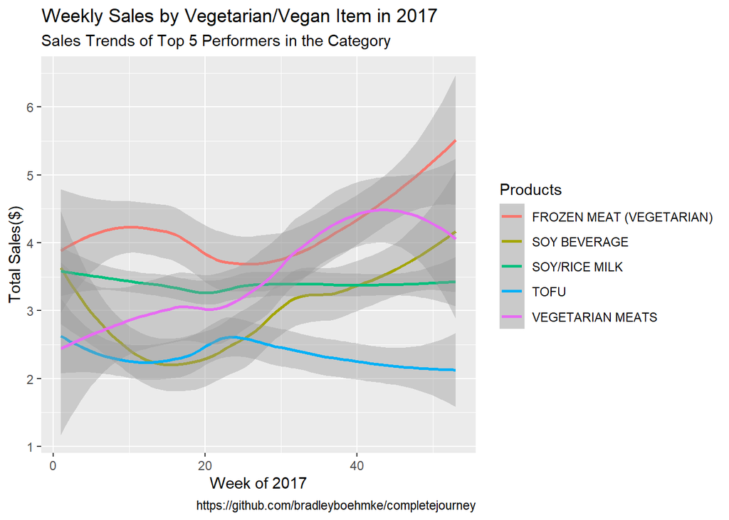

```r
print(VegeWeeklySalesTrends)
```

```r
VegeProductWeeklySalesPerc
```

```
## # A tibble: 5 × 2
##   product_type             averagePercChange
##   <chr>                                <dbl>
## 1 FROZEN MEAT (VEGETARIAN)             11.5
## 2 SOY BEVERAGE                         18.1
## 3 SOY/RICE MILK                         9.40
## 4 TOFU                                 10.8
## 5 VEGETARIAN MEATS                     21.8
```

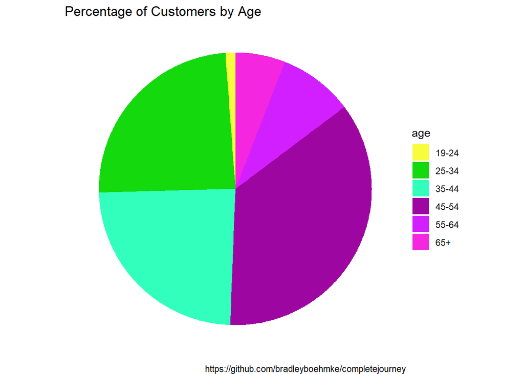

```r
# Print the first demographic plot (VegePieAge)
print(VegePieAge)
```

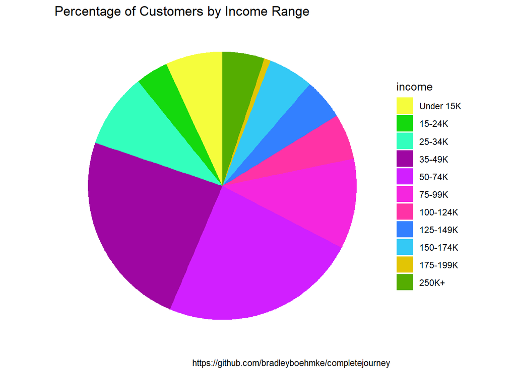

```r
# Print the second demographicplot (VegePieIncome)
print(VegePieIncome)
```

These graphs reveal the distribution of vegetarian and vegan product sales by age group and income brackets. This information helps us understand which age demographics are more likely to purchase these products.

```r
 print(VegePieHouseComp)
```

[figure not shown]

Household composition analysis allows us to see the types of households—single-person, families, etc.—that are more likely to consume vegetarian and vegan products. In combination with the Age and Income graphs above, we can leverage this data to understand which demographics we should be advertising any new Vegetarian/Vegan friendly products to. The data shows us a clear picture of relevant demographics: - These product purchasers are in 25 - 54 age range - These purchasers are most typically in the 35k-74k income bracket - Purchasers are typically from 2 adult households

#### Locations and Advertising Pairing

Stores and Items that work well with Vegetarian/Vegan Selections

[figure not shown]

```
This section shows which stores have the highest sales for the vegetarian and vegan products we identified. By identifying these locations, we can focus advertising efforts and product placement strategies to maximize sales in high-performing regions. The top performers are stores 367, 381, and 321.
```

[output not shown]

```r
print(VegeStoreGraph)
```

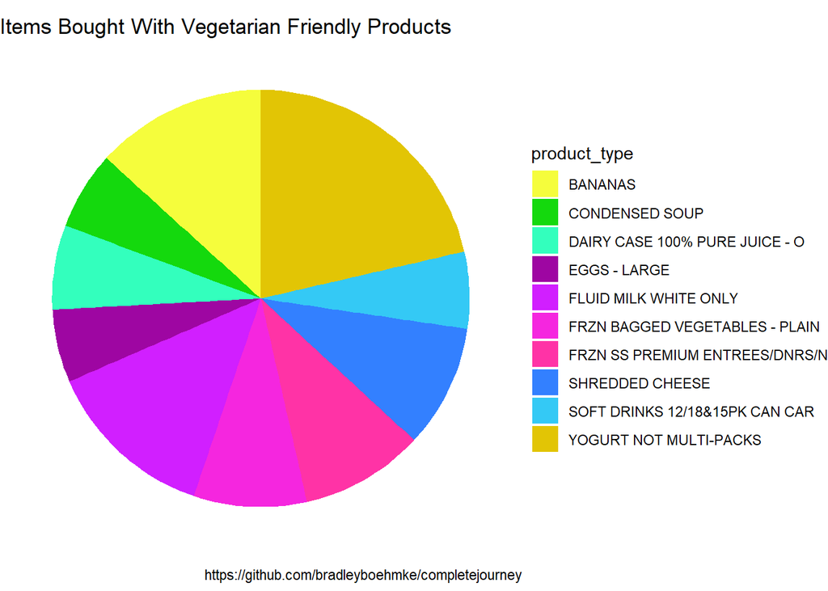

```r
print(VegePieAdjacent)
```

### Summary

#### Who are the current demographics buying these products? Who should we be marketing new entries to?

Our analysis of customer demographics revealed a clear profile of the consumers who would likely welcome the introduction of new vegetarian and vegan products. A significant portion of purchasers falls within the 25-54 age range and the $34k-$74k income bracket. Additionally, most of these consumers are from two-adult households, with or without children, or single-adult households without children. With this information, we can focus our advertising efforts on the demographics most likely to respond positively to new vegetarian or vegan offerings.

#### Where can we do test runs, and what products can be paired with these options?

In examining the stores with the highest sales, stores 367, 381, and 321 were top performers. These locations, along with the rest in the top 10, provide lower-risk environments to test new product rollouts. An established customer base in these stores gives us confidence that we are targeting consumers already interested in these types of products. Additionally, we analyzed the items frequently purchased alongside vegetarian and vegan-friendly products. Items such as bananas, yogurt (pints and quarts), and white milk were often found in the same baskets as these options. This information helps us determine where to position these products to maximize visibility and encourage cross-selling.

#### Our Recommendation

Based on the analysis, we recommend expanding the Vegetarian and Vegan categories as we move into the next year. These products are aligned with both market trends and consumer demand, including among those who shop at our stores. The insights provided in this report should guide the introduction of new products in ways that capture consumer attention while minimizing any potential risks.